# Flight Delay & Cancellations Analysis

## Introduction

This project investigates on questions related to flight delays and flight cancellations, and it aims to share some insights for relevant entities on how to avoid delays and optimize the operation of relevant facilities. The main topics include: in which month(s) do flight delays occur most frequently? Do fly delays happen more during the daytime or the nighttime? Is the frequency of flight delays correlated to the ariline carriers in any way?

Plus, scroll down to the end to find some visualization depicting and showcasing more in-depth analysis!

*The U.S. Department of Transportation's (DOT) Bureau of Transportation Statistics tracks the on-time performance of domestic flights operated by large air carriers. Summary information on the number of on-time, delayed, canceled, and diverted flights is published in DOT's monthly Air Travel Consumer Report and in this [dataset](https://www.kaggle.com/usdot/flight-delays) of 2015 flight delays and cancellations.*

### Notes before Getting Started

For this relatively large dataset, explanations to better utilize the data for analysis are as follows.

1. For day of the week, 1 means Monday, while 7 means Sunday - this could be verified by checking what day is it for 2015/1/1 on the calendar, and it is an Thursday, noted as "4" in the dataset.
2. For delays, there are departure delays and arrival delays. Consider these two situations separately.
3. In terms of earlier in the day versus later in the day, use 1200 as the cut-off point, as in 12pm (noon) in real life context. When it is equal to 1200, consider it as the later of the day, as 0000 (12am) is taken in as earlier of the day.
4. To determine whether the flight is in earlier or later of the day, check the scheduled departure and scheduled arrival time accordingly.
5. For the cancelled flights, there are only scheduled departure time recorded in the dataset.
6. When it comes to taxi times, consider taxi out for origin airports, and taxi in for destination airports.

```python
## Starter code

# Import relevant packages
import pandas as pd
import numpy as np
import matplotlib.pyplot as plt
import matplotlib.cm as cm
import matplotlib.colors
import matplotlib.cm as cm
import matplotlib.colors

import warnings
warnings.filterwarnings('ignore')

# The following statements should get the three data files loaded as DataFrames.

airlines = pd.read_csv("C:/Users/liyxk/OneDrive/Documents/GoGetIt/Github Files/flightdata/airlines.csv")
airports = pd.read_csv("C:/Users/liyxk/OneDrive/Documents/GoGetIt/Github Files/flightdata/airports.csv")
flights  = pd.read_csv("C:/Users/liyxk/OneDrive/Documents/GoGetIt/Github Files/flightdata/flights.csv")
# the flights file is ~140mb so will take a few seconds to load
```

## Topic 1

### *Do flight delays happen more often later in the day compared to earlier in the day?*

From the results, we could conclude that both departure delays and arrival delays happened more often later in the day in 2015. Arrival delays are more pronounced in this pattern - for arrival delays, those happened later in the day takes up a bigger proportion of total arrival delays. For departure delays, those happened later in the day takes up a smaller proportion of total departure delays, relatively.

This result kind of makes sense as airline companies normally line up their flights by available air crafts. If one flight is delayed earlier in the day, the situation would accumulate and affect the next flight that is supposed to be flew with the same air craft.

```python
delays = pd.DataFrame(flights)

delays['DEPARTURE_DELAY_YN'] = delays['DEPARTURE_DELAY'] > 0
delays['ARRIVAL_DELAY_YN'] = delays['ARRIVAL_DELAY'] > 0

# For departure delays
early_departure = (delays['SCHEDULED_DEPARTURE'] < 1200) & (delays['DEPARTURE_DELAY_YN'] == True)
sum(early_departure)

late_departure = (delays['SCHEDULED_DEPARTURE'] >= 1200) & (delays['DEPARTURE_DELAY_YN'] == True)
sum(late_departure)

# For arrival delays
early_arrival = (delays['SCHEDULED_ARRIVAL'] < 1200) & (delays['ARRIVAL_DELAY_YN'] == True)
sum(early_arrival)

late_arrival = (delays['SCHEDULED_ARRIVAL'] >= 1200) & (delays['ARRIVAL_DELAY_YN'] == True)
sum(late_arrival)

# Results
print("Departure delays that happened earlier in the day:", sum(early_departure))
print("Departure delays that happened later in the day:", sum(late_departure))
print("Arrival delays that happened eariler in the day:", sum(early_arrival))
print("Arrival delays that happened later in the day:", sum(late_arrival))

rate1 = sum(late_departure)/(sum(early_departure)+sum(late_departure))
rate2 = sum(late_arrival)/(sum(early_arrival)+sum(late_arrival))

print(rate1)
print(rate2)
```

```
Departure delays that happened earlier in the day: 639489
Departure delays that happened later in the day: 1486129
Arrival delays that happened eariler in the day: 499698
Arrival delays that happened later in the day: 1587198
0.6991514938243842
0.7605544310785013
```

```python
# Alternative solution to Topic 1

# List conditions.
early_dep = (flights.SCHEDULED_DEPARTURE < 1200)
late_dep = (flights.SCHEDULED_DEPARTURE >= 1200)
early_arr = (flights.SCHEDULED_ARRIVAL < 1200)
late_arr = (flights.SCHEDULED_ARRIVAL >= 1200)
dep_delay = (flights.DEPARTURE_DELAY > 0)
arr_delay = (flights.ARRIVAL_DELAY > 0)

timedep_labels = ['early', 'late']
timedep_conditions = [early_dep, late_dep]
timearr_labels = ['early', 'late']
timearr_conditions = [early_arr, late_arr]
delay_labels = ['departure', 'arrival']
delay_conditions = [dep_delay, arr_delay]

for i in range(len(timedep_labels)):
    for m in range(len(delay_labels)):
        if delay_labels[m] == 'departure':
            print(f'{timedep_labels[i]} {delay_labels[m]} delays:')
            df = flights[timedep_conditions[i] & delay_conditions[m]]
            print(f'{len(df)} \n')
        else:
            pass

for i in range(len(timearr_labels)):
    for m in range(len(delay_labels)):
        if delay_labels[m] == 'arrival':
            print(f'{timearr_labels[i]} {delay_labels[m]} delays:')
            df = flights[timearr_conditions[i] & delay_conditions[m]]
            print(f'{len(df)} \n')
        else:
            pass
```

```
early departure delays:
639489

late departure delays:
1486129

early arrival delays:
499698

late arrival delays:
1587198
```

## Topic 2

### *Does the response to Topic 1 depend on the month of the year?*

No, the response to Topic 1 does not depend on the month of the year - as in for each month in 2015, both departure delays and arrival delays happened more often later in the day.

For departure delays, looking at the proportion that the late delays take up out of the total delays, May had this phenomenon most pronounced in 2015; December had this phenomenon least pronounced in 2015.

```python
# departure delays
print("For departure delays:")
dep_month_early = pd.DataFrame([])
dep_month_late = pd.DataFrame([])

for i in range(len(timedep_labels)):
    for m in range(len(delay_labels)):
        if delay_labels[m] == "departure":
            print(f'{timedep_labels[i]} {delay_labels[m]} delays:')
            df = flights[timedep_conditions[i] & delay_conditions[m]].groupby(['MONTH']).agg({'YEAR': len}).rename(columns = {'YEAR': 'num_of_delays'})
            display(df)
            if timedep_labels[i] == "early":
                dep_month_early = dep_month_early.append(df)
            else:
                dep_month_late = dep_month_late.append(df)
        else:
            pass

dep_month = pd.merge(dep_month_early, dep_month_late, left_index=True, right_index=True)
dep_month['total'] = dep_month['num_of_delays_x'] + dep_month['num_of_delays_y']
dep_month['late_rate'] = dep_month['num_of_delays_y']/dep_month['total']
print(dep_month)
print("")


# arrival delays
print("For arrival delays:")
arr_month_early = pd.DataFrame([])
arr_month_late = pd.DataFrame([])

for i in range(len(timearr_labels)):
    for m in range(len(delay_labels)):
        if delay_labels[m] == "arrival":
            print(f'{timearr_labels[i]} {delay_labels[m]} delays:')
            df = flights[timearr_conditions[i] & delay_conditions[m]].groupby(['MONTH']).agg({'YEAR': len}).rename(columns = {'YEAR': 'num_of_delays'})
            display(df)
            if timedep_labels[i] == "early":
                arr_month_early = arr_month_early.append(df)
            else:
                arr_month_late = arr_month_late.append(df)
        else:
            pass

arr_month = pd.merge(arr_month_early, arr_month_late, left_index=True, right_index=True)
arr_month['total'] = arr_month['num_of_delays_x'] + arr_month['num_of_delays_y']
arr_month['late_rate'] = arr_month['num_of_delays_y']/arr_month['total']
print(arr_month)
```

```
For departure delays:
early departure delays:
```

| MONTH | num_of_delays |
| --- | --- |
| 1 | 55290 |
| 2 | 54200 |
| 3 | 58322 |
| 4 | 49326 |
| 5 | 50762 |
| 6 | 62978 |
| 7 | 60175 |
| 8 | 55608 |
| 9 | 39223 |
| 10 | 45056 |
| 11 | 46702 |
| 12 | 61847 |

```
late departure delays:
```

| MONTH | num_of_delays |
| --- | --- |
| 1 | 121337 |
| 2 | 119242 |
| 3 | 135495 |
| 4 | 117988 |
| 5 | 128094 |
| 6 | 152403 |
| 7 | 149444 |
| 8 | 135232 |
| 9 | 93368 |
| 10 | 100046 |
| 11 | 105988 |
| 12 | 127492 |

```
       num_of_delays_x  num_of_delays_y   total  late_rate
MONTH
1                55290           121337  176627   0.686967
2                54200           119242  173442   0.687504
3                58322           135495  193817   0.699087
4                49326           117988  167314   0.705189
5                50762           128094  178856   0.716185
6                62978           152403  215381   0.707597
7                60175           149444  209619   0.712932
8                55608           135232  190840   0.708615
9                39223            93368  132591   0.704181
10               45056           100046  145102   0.689487
11               46702           105988  152690   0.694138
12               61847           127492  189339   0.673353

For arrival delays:
early arrival delays:
```

| MONTH | num_of_delays |
| --- | --- |
| 1 | 42611 |
| 2 | 40604 |
| 3 | 45706 |
| 4 | 43012 |
| 5 | 39878 |
| 6 | 49559 |
| 7 | 46928 |
| 8 | 42318 |
| 9 | 30742 |
| 10 | 34711 |
| 11 | 37027 |
| 12 | 46602 |

```
late arrival delays:
```

| MONTH | num_of_delays |
| --- | --- |
| 1 | 140499 |
| 2 | 134839 |
| 3 | 144427 |
| 4 | 128808 |
| 5 | 135300 |
| 6 | 157430 |
| 7 | 152789 |
| 8 | 138573 |
| 9 | 102690 |
| 10 | 106539 |
| 11 | 112412 |
| 12 | 132892 |

```
       num_of_delays_x  num_of_delays_y   total  late_rate
MONTH
1                42611           140499  183110   0.767293
2                40604           134839  175443   0.768563
3                45706           144427  190133   0.759610
4                43012           128808  171820   0.749668
5                39878           135300  175178   0.772357
6                49559           157430  206989   0.760572
7                46928           152789  199717   0.765028
8                42318           138573  180891   0.766058
9                30742           102690  133432   0.769605
10               34711           106539  141250   0.754258
11               37027           112412  149439   0.752227
12               46602           132892  179494   0.740370
```

```python
# Alternative solution to Topic 2

# Jan
print("January")
early_departure_jan = (delays['MONTH'] == 1) & (delays['SCHEDULED_DEPARTURE'] < 1200) & (delays['DEPARTURE_DELAY_YN'] == True)
print("Early departure delays:",sum(early_departure_jan))
late_departure_jan = (delays['MONTH'] == 1) & (delays['SCHEDULED_DEPARTURE'] >= 1200) & (delays['DEPARTURE_DELAY_YN'] == True)
print("Late departure delays:",sum(late_departure_jan))
early_arrival_jan = (delays['MONTH'] == 1) &  (delays['SCHEDULED_ARRIVAL'] < 1200) & (delays['ARRIVAL_DELAY_YN'] == True)
print("Early arrival delays:",sum(early_arrival_jan))
late_arrival_jan = (delays['MONTH'] == 1) & (delays['SCHEDULED_ARRIVAL'] >= 1200) & (delays['ARRIVAL_DELAY_YN'] == True)
print("Late arrival delays:",sum(late_arrival_jan))
print("\n")

# Feb
print("February")
early_departure_feb = (delays['MONTH'] == 2) & (delays['SCHEDULED_DEPARTURE'] < 1200) & (delays['DEPARTURE_DELAY_YN'] == True)
print("Early departure delays:",sum(early_departure_feb))
late_departure_feb = (delays['MONTH'] == 2) & (delays['SCHEDULED_DEPARTURE'] >= 1200) & (delays['DEPARTURE_DELAY_YN'] == True)
print("Late departure delays:",sum(late_departure_feb))
early_arrival_feb = (delays['MONTH'] == 2) &  (delays['SCHEDULED_ARRIVAL'] < 1200) & (delays['ARRIVAL_DELAY_YN'] == True)
print("Early arrival delays:",sum(early_arrival_feb))
late_arrival_feb = (delays['MONTH'] == 2) & (delays['SCHEDULED_ARRIVAL'] >= 1200) & (delays['ARRIVAL_DELAY_YN'] == True)
print("Late arrival delays:",sum(late_arrival_feb))
print("\n")


# March
print("March")
early_departure_mar = (delays['MONTH'] == 3) & (delays['SCHEDULED_DEPARTURE'] < 1200) & (delays['DEPARTURE_DELAY_YN'] == True)
print("Early departure delays:",sum(early_departure_mar))
late_departure_mar = (delays['MONTH'] == 3) & (delays['SCHEDULED_DEPARTURE'] >= 1200) & (delays['DEPARTURE_DELAY_YN'] == True)
print("Late departure delays:",sum(late_departure_mar))
early_arrival_mar = (delays['MONTH'] == 3) &  (delays['SCHEDULED_ARRIVAL'] < 1200) & (delays['ARRIVAL_DELAY_YN'] == True)
print("Early arrival delays:",sum(early_arrival_mar))
late_arrival_mar = (delays['MONTH'] == 3) & (delays['SCHEDULED_ARRIVAL'] >= 1200) & (delays['ARRIVAL_DELAY_YN'] == True)
print("Late arrival delays:",sum(late_arrival_mar))
print("\n")


# April
print("April")
early_departure_april = (delays['MONTH'] == 4) & (delays['SCHEDULED_DEPARTURE'] < 1200) & (delays['DEPARTURE_DELAY_YN'] == True)
print("Early departure delays:",sum(early_departure_april))
late_departure_april = (delays['MONTH'] == 4) & (delays['SCHEDULED_DEPARTURE'] >= 1200) & (delays['DEPARTURE_DELAY_YN'] == True)
print("Late departure delays:",sum(late_departure_april))
early_arrival_april = (delays['MONTH'] == 4) &  (delays['SCHEDULED_ARRIVAL'] < 1200) & (delays['ARRIVAL_DELAY_YN'] == True)
print("Early arrival delays:",sum(early_arrival_april))
late_arrival_april = (delays['MONTH'] == 4) & (delays['SCHEDULED_ARRIVAL'] >= 1200) & (delays['ARRIVAL_DELAY_YN'] == True)
print("Late arrival delays:",sum(late_arrival_april))
print("\n")


# May
print("May")
early_departure_may = (delays['MONTH'] == 5) & (delays['SCHEDULED_DEPARTURE'] < 1200) & (delays['DEPARTURE_DELAY_YN'] == True)
print("Early departure delays:",sum(early_departure_may))
late_departure_may = (delays['MONTH'] == 5) & (delays['SCHEDULED_DEPARTURE'] >= 1200) & (delays['DEPARTURE_DELAY_YN'] == True)
print("Late departure delays:",sum(late_departure_may))
early_arrival_may = (delays['MONTH'] == 5) &  (delays['SCHEDULED_ARRIVAL'] < 1200) & (delays['ARRIVAL_DELAY_YN'] == True)
print("Early arrival delays:",sum(early_arrival_may))
late_arrival_may = (delays['MONTH'] == 5) & (delays['SCHEDULED_ARRIVAL'] >= 1200) & (delays['ARRIVAL_DELAY_YN'] == True)
print("Late arrival delays:",sum(late_arrival_may))
print("\n")


# June
print("June")
early_departure_june = (delays['MONTH'] == 6) & (delays['SCHEDULED_DEPARTURE'] < 1200) & (delays['DEPARTURE_DELAY_YN'] == True)
print("Early departure delays:",sum(early_departure_june))
late_departure_june = (delays['MONTH'] == 6) & (delays['SCHEDULED_DEPARTURE'] >= 1200) & (delays['DEPARTURE_DELAY_YN'] == True)
print("Late departure delays:",sum(late_departure_june))
early_arrival_june = (delays['MONTH'] == 6) &  (delays['SCHEDULED_ARRIVAL'] < 1200) & (delays['ARRIVAL_DELAY_YN'] == True)
print("Early arrival delays:",sum(early_arrival_june))
late_arrival_june = (delays['MONTH'] == 6) & (delays['SCHEDULED_ARRIVAL'] >= 1200) & (delays['ARRIVAL_DELAY_YN'] == True)
print("Late arrival delays:",sum(late_arrival_june))
print("\n")

# July
print("July")
early_departure_july = (delays['MONTH'] == 7) & (delays['SCHEDULED_DEPARTURE'] < 1200) & (delays['DEPARTURE_DELAY_YN'] == True)
print("Early departure delays:",sum(early_departure_july))
late_departure_july = (delays['MONTH'] == 7) & (delays['SCHEDULED_DEPARTURE'] >= 1200) & (delays['DEPARTURE_DELAY_YN'] == True)
print("Late departure delays:",sum(late_departure_july))
early_arrival_july = (delays['MONTH'] == 7) &  (delays['SCHEDULED_ARRIVAL'] < 1200) & (delays['ARRIVAL_DELAY_YN'] == True)
print("Early arrival delays:",sum(early_arrival_july))
late_arrival_july = (delays['MONTH'] == 7) & (delays['SCHEDULED_ARRIVAL'] >= 1200) & (delays['ARRIVAL_DELAY_YN'] == True)
print("Late arrival delays:",sum(late_arrival_july))
print("\n")

# August
print("August")
early_departure_aug = (delays['MONTH'] == 8) & (delays['SCHEDULED_DEPARTURE'] < 1200) & (delays['DEPARTURE_DELAY_YN'] == True)
print("Early departure delays:",sum(early_departure_aug))
late_departure_aug = (delays['MONTH'] == 8) & (delays['SCHEDULED_DEPARTURE'] >= 1200) & (delays['DEPARTURE_DELAY_YN'] == True)
print("Late departure delays:",sum(late_departure_aug))
early_arrival_aug = (delays['MONTH'] == 8) &  (delays['SCHEDULED_ARRIVAL'] < 1200) & (delays['ARRIVAL_DELAY_YN'] == True)
print("Early arrival delays:",sum(early_arrival_aug))
late_arrival_aug = (delays['MONTH'] == 8) & (delays['SCHEDULED_ARRIVAL'] >= 1200) & (delays['ARRIVAL_DELAY_YN'] == True)
print("Late arrival delays:",sum(late_arrival_aug))
print("\n")

# September
print("September")
early_departure_sept = (delays['MONTH'] == 9) & (delays['SCHEDULED_DEPARTURE'] < 1200) & (delays['DEPARTURE_DELAY_YN'] == True)
print("Early departure delays:",sum(early_departure_sept))
late_departure_sept = (delays['MONTH'] == 9) & (delays['SCHEDULED_DEPARTURE'] >= 1200) & (delays['DEPARTURE_DELAY_YN'] == True)
print("Late departure delays:",sum(late_departure_sept))
early_arrival_sept = (delays['MONTH'] == 9) &  (delays['SCHEDULED_ARRIVAL'] < 1200) & (delays['ARRIVAL_DELAY_YN'] == True)
print("Early arrival delays:",sum(early_arrival_sept))
late_arrival_sept = (delays['MONTH'] == 9) & (delays['SCHEDULED_ARRIVAL'] >= 1200) & (delays['ARRIVAL_DELAY_YN'] == True)
print("Late arrival delays:",sum(late_arrival_sept))
print("\n")

# October
print("October")
early_departure_oct = (delays['MONTH'] == 10) & (delays['SCHEDULED_DEPARTURE'] < 1200) & (delays['DEPARTURE_DELAY_YN'] == True)
print("Early departure delays:",sum(early_departure_oct))
late_departure_oct = (delays['MONTH'] == 10) & (delays['SCHEDULED_DEPARTURE'] >= 1200) & (delays['DEPARTURE_DELAY_YN'] == True)
print("Late departure delays:",sum(late_departure_oct))
early_arrival_oct = (delays['MONTH'] == 10) &  (delays['SCHEDULED_ARRIVAL'] < 1200) & (delays['ARRIVAL_DELAY_YN'] == True)
print("Early arrival delays:",sum(early_arrival_oct))
late_arrival_oct = (delays['MONTH'] == 10) & (delays['SCHEDULED_ARRIVAL'] >= 1200) & (delays['ARRIVAL_DELAY_YN'] == True)
print("Late arrival delays:",sum(late_arrival_oct))
print("\n")

# November
print("November")
early_departure_nov = (delays['MONTH'] == 11) & (delays['SCHEDULED_DEPARTURE'] < 1200) & (delays['DEPARTURE_DELAY_YN'] == True)
print("Early departure delays:",sum(early_departure_nov))
late_departure_nov = (delays['MONTH'] == 11) & (delays['SCHEDULED_DEPARTURE'] >= 1200) & (delays['DEPARTURE_DELAY_YN'] == True)
print("Late departure delays:",sum(late_departure_nov))
early_arrival_nov = (delays['MONTH'] == 11) &  (delays['SCHEDULED_ARRIVAL'] < 1200) & (delays['ARRIVAL_DELAY_YN'] == True)
print("Early arrival delays:",sum(early_arrival_nov))
late_arrival_nov = (delays['MONTH'] == 11) & (delays['SCHEDULED_ARRIVAL'] >= 1200) & (delays['ARRIVAL_DELAY_YN'] == True)
print("Late arrival delays:",sum(late_arrival_nov))
print("\n")

# December
print("December")
early_departure_dec = (delays['MONTH'] == 12) & (delays['SCHEDULED_DEPARTURE'] < 1200) & (delays['DEPARTURE_DELAY_YN'] == True)
print("Early departure delays:",sum(early_departure_dec))
late_departure_dec = (delays['MONTH'] == 12) & (delays['SCHEDULED_DEPARTURE'] >= 1200) & (delays['DEPARTURE_DELAY_YN'] == True)
print("Late departure delays:",sum(late_departure_dec))
early_arrival_dec = (delays['MONTH'] == 12) &  (delays['SCHEDULED_ARRIVAL'] < 1200) & (delays['ARRIVAL_DELAY_YN'] == True)
print("Early arrival delays:",sum(early_arrival_dec))
late_arrival_dec = (delays['MONTH'] == 12) & (delays['SCHEDULED_ARRIVAL'] >= 1200) & (delays['ARRIVAL_DELAY_YN'] == True)
print("Late arrival delays:",sum(late_arrival_dec))
print("\n")
```

```
January
Early departure delays: 55290
Late departure delays: 121337
Early arrival delays: 42611
Late arrival delays: 140499


February
Early departure delays: 54200
Late departure delays: 119242
Early arrival delays: 40604
Late arrival delays: 134839


March
Early departure delays: 58322
Late departure delays: 135495
Early arrival delays: 45706
Late arrival delays: 144427


April
Early departure delays: 49326
Late departure delays: 117988
Early arrival delays: 43012
Late arrival delays: 128808


May
Early departure delays: 50762
Late departure delays: 128094
Early arrival delays: 39878
Late arrival delays: 135300


June
Early departure delays: 62978
Late departure delays: 152403
Early arrival delays: 49559
Late arrival delays: 157430
```

[output cut: 27 more lines]

```
Late arrival delays: 106539


November
Early departure delays: 46702
Late departure delays: 105988
Early arrival delays: 37027
Late arrival delays: 112412


December
Early departure delays: 61847
Late departure delays: 127492
Early arrival delays: 46602
Late arrival delays: 132892
```

## Topic 3

### *Does the response to Topic 1 depend on the airline? Which airlines have this phenomenon more pronounced and less pronounced?*

The resposne to Topic 1 does not depend on the airline - as for all the airlines included, both departure delays and arrival delays happened more often later in the day than earlier in the day.

For arrival delays, looking at the proportion that the late delays take up out of the total delays, airline WN, as in Southwest Airlines had this phenomenon most pronounced in 2015; airline NK, as in Spirit Airlines had this phenomenon least pronounced in 2015.

```python
# depature delays
print("For departure delays:")
dep_airline_early = pd.DataFrame([])
dep_airline_late = pd.DataFrame([])

for i in range(len(timedep_labels)):
    for m in range(len(delay_labels)):
        if delay_labels[m] == "departure":
            print(f'{timedep_labels[i]} {delay_labels[m]} delays:')
            df = flights[timedep_conditions[i] & delay_conditions[m]].groupby(['AIRLINE']).agg({'YEAR': len}).rename(columns = {'YEAR': 'num_of_delays'})
            display(df)
            if timedep_labels[i] == "early":
                dep_airline_early = dep_airline_early.append(df)
            else:
                dep_airline_late = dep_airline_late.append(df)
        else:
            pass

dep_airline = pd.merge(dep_airline_early, dep_airline_late, left_index=True, right_index=True)
dep_airline['total'] = dep_airline['num_of_delays_x'] + dep_airline['num_of_delays_y']
dep_airline['late_rate'] = dep_airline['num_of_delays_y']/dep_airline['total']
print(dep_airline)
print("")

# arrival delays
print("For arrival delays:")
arr_airline_early = pd.DataFrame([])
arr_airline_late = pd.DataFrame([])
# arrival delays
for i in range(len(timearr_labels)):
    for m in range(len(delay_labels)):
        if delay_labels[m] == "arrival":
            print(f'{timearr_labels[i]} {delay_labels[m]} delays:')
            df = flights[timearr_conditions[i] & delay_conditions[m]].groupby(['AIRLINE']).agg({'YEAR': len}).rename(columns = {'YEAR': 'num_of_delays'})
            display(df)
            if timearr_labels[i] == "early":
                arr_airline_early = arr_airline_early.append(df)
            else:
                arr_airline_late = arr_airline_late.append(df)
        else:
            pass

arr_airline = pd.merge(arr_airline_early, arr_airline_late, left_index=True, right_index=True)
arr_airline['total'] = arr_airline['num_of_delays_x'] + arr_airline['num_of_delays_y']
arr_airline['late_rate'] = arr_airline['num_of_delays_y']/arr_airline['total']

print(arr_airline)
```

```
For departure delays:
early departure delays:
```

| AIRLINE | num_of_delays |
| --- | --- |
| AA | 77209 |
| AS | 15447 |
| B6 | 26716 |
| DL | 85331 |
| EV | 52620 |
| F9 | 10376 |
| HA | 5360 |
| MQ | 30139 |
| NK | 17588 |
| OO | 54447 |
| UA | 89876 |
| US | 19829 |
| VX | 7786 |
| WN | 146765 |

```
late departure delays:
```

| AIRLINE | num_of_delays |
| --- | --- |
| AA | 168695 |
| AS | 28119 |
| B6 | 75345 |
| DL | 197132 |
| EV | 117277 |
| F9 | 24517 |
| HA | 14786 |
| MQ | 63587 |
| NK | 34501 |
| OO | 117125 |
| UA | 166674 |
| US | 42736 |
| VX | 15593 |
| WN | 420042 |

```
         num_of_delays_x  num_of_delays_y   total  late_rate
AIRLINE
AA                 77209           168695  245904   0.686020
AS                 15447            28119   43566   0.645435
B6                 26716            75345  102061   0.738235
DL                 85331           197132  282463   0.697904
EV                 52620           117277  169897   0.690283
F9                 10376            24517   34893   0.702634
HA                  5360            14786   20146   0.733942
MQ                 30139            63587   93726   0.678435
NK                 17588            34501   52089   0.662347
OO                 54447           117125  171572   0.682658
UA                 89876           166674  256550   0.649675
US                 19829            42736   62565   0.683066
VX                  7786            15593   23379   0.666966
WN                146765           420042  566807   0.741067

For arrival delays:
early arrival delays:
```

| AIRLINE | num_of_delays |
| --- | --- |
| AA | 60401 |
| AS | 15040 |
| B6 | 26602 |
| DL | 61967 |
| EV | 54976 |
| F9 | 10472 |
| HA | 7841 |
| MQ | 28991 |
| NK | 17372 |
| OO | 56282 |
| UA | 45552 |
| US | 19605 |
| VX | 4809 |
| WN | 89788 |

```
late arrival delays:
```

| AIRLINE | num_of_delays |
| --- | --- |
| AA | 191790 |
| AS | 41913 |
| B6 | 75396 |
| DL | 188873 |
| EV | 158241 |
| F9 | 30760 |
| HA | 22338 |
| MQ | 74514 |
| NK | 39515 |
| OO | 166153 |
| UA | 140675 |
| US | 56680 |
| VX | 19371 |
| WN | 380979 |

```
         num_of_delays_x  num_of_delays_y   total  late_rate
AIRLINE
AA                 60401           191790  252191   0.760495
AS                 15040            41913   56953   0.735923
B6                 26602            75396  101998   0.739191
DL                 61967           188873  250840   0.752962
EV                 54976           158241  213217   0.742159
F9                 10472            30760   41232   0.746023
HA                  7841            22338   30179   0.740184
MQ                 28991            74514  103505   0.719907
NK                 17372            39515   56887   0.694623
OO                 56282           166153  222435   0.746973
UA                 45552           140675  186227   0.755395
US                 19605            56680   76285   0.743003
VX                  4809            19371   24180   0.801117
WN                 89788           380979  470767   0.809273
```

## Topic 4

### *Do flight cancellations happen more often later in the day than earlier in the day?*

From the output below, flight cancellations happened more often later in the day in general. To be specific, around 62% of the flight cancellations happened later in the day in 2015. Rationale identical to the one for delayed flights could be applied here as well - if something is wrong with a certain flight earlier in the day, the flight using the same air craft later that day would be more likely to be cancelled.

```python
cancel = pd.DataFrame(flights)

cancel_early = (cancel['CANCELLED'] == 1) & (cancel['SCHEDULED_DEPARTURE'] < 1200)
sum(cancel_early)

cancel_late =(cancel['CANCELLED'] == 1) & (cancel['SCHEDULED_DEPARTURE'] >= 1200)
sum(cancel_late)

rate_cancel = sum(cancel_late)/(sum(cancel_early)+sum(cancel_late))

print("Flight cancellations that happened earlier in the day:", sum(cancel_early))
print("Flight cancellations that happened later in the day:", sum(cancel_late))
print("The proportion of flight cancellations that happened later in the day out of total flight cancellations:", round(rate_cancel,2))
```

```
Flight cancellations that happened earlier in the day: 33799
Flight cancellations that happened later in the day: 56085
The proportion of flight cancellations that happened later in the day out of total flight cancellations: 0.62
```

## Topic 5

### *Does the response to Topic 4 depend on the month of the year and on the airline?*

The response to Topic 4 does not depend on the month of the year - as in for every month in 2015, cancellations happened more often later in the day. To be specific, June of 2015 had this phenomenon most pronounced, while January of 2015 had this phenomenon least pronounced.

*For more about this issue, check again on Viz #7.*

```python
# List conditions.
cancelled = (flights.CANCELLED == 1)

dep_new_e = (flights['SCHEDULED_DEPARTURE'] < 1200)
dep_new_l = (flights['SCHEDULED_DEPARTURE'] >= 1200)

print("Cancellations by Month:")
# Cancellations Early in the Day by Month
monthly_early_cancel = flights[early_dep & cancelled].groupby(['MONTH']).agg({'MONTH': len}).rename(columns = {'MONTH':'num_cancel'})
print("Cancellations Early in the Day")
print(monthly_early_cancel)
print("")

# Cancellations Late in the Day by Month
monthly_later_cancel = flights[late_dep & cancelled].groupby(['MONTH']).agg({'MONTH': len}).rename(columns = {'MONTH':'num_cancel'})
print("Cancellations Late in the Day")
print(monthly_later_cancel)
print('')

cancel_month = pd.merge(monthly_early_cancel, monthly_later_cancel, left_index = True, right_index = True)
cancel_month['total'] = cancel_month['num_cancel_x'] + cancel_month['num_cancel_y']
cancel_month['late_perc'] = cancel_month['num_cancel_y']/cancel_month['total']
print(cancel_month)
print("")


print("Cancellations by Airline:")
# Cancellations Early in the Day by Airline
al_early_cancel = flights[early_dep & cancelled].groupby(['AIRLINE']).agg({'AIRLINE': len}).rename(columns = {'AIRLINE':'num_cancel'})
print("Cancellations Early in the Day")
print(al_early_cancel)
print("")

# Cancellations Late in the Day by Airline
al_later_cancel = flights[late_dep & cancelled].groupby(['AIRLINE']).agg({'AIRLINE': len}).rename(columns = {'AIRLINE':'num_cancel'})
print("Cancellations Late in the Day")
print(al_later_cancel)
print("")

cancel_al = pd.merge(al_early_cancel, al_later_cancel, left_index = True, right_index = True).rename(columns = {'num_cancel_x':'x', 'num_cancel_y':'y'})
cancel_al['total'] = cancel_al['x'] + cancel_al['y']
cancel_al['late_perc'] = cancel_al['y']/cancel_al['total']
print(cancel_al)
```

```
Cancellations by Month:
Cancellations Early in the Day
       num_cancel
MONTH
1            5100
2            8539
3            4472
4            1740
5            1850
6            2730
7            1580
8            1669
9             630
10            861
11           1749
12           2879

Cancellations Late in the Day
       num_cancel
MONTH
1            6882
2           11978
3            6530
4            2780
5            3844
6            6390
7            3226
8            3383
9            1445
10           1593
11           2850
12           5184

       num_cancel_x  num_cancel_y  total  late_perc
MONTH
1              5100          6882  11982   0.574362
2              8539         11978  20517   0.583809
3              4472          6530  11002   0.593528
4              1740          2780   4520   0.615044
5              1850          3844   5694   0.675097
```

[output cut: 46 more lines]

```
AIRLINE
AA       4498   6421  10919   0.588058
AS        273    396    669   0.591928
B6       1698   2578   4276   0.602900
DL       1517   2307   3824   0.603295
EV       4872  10359  15231   0.680126
F9        175    413    588   0.702381
HA         48    123    171   0.719298
MQ       5217   9808  15025   0.652779
NK        652   1352   2004   0.674651
OO       3475   6485   9960   0.651104
UA       2642   3931   6573   0.598053
US       1711   2356   4067   0.579297
VX        248    286    534   0.535581
WN       6773   9270  16043   0.577822
```

## Topic 6

### *State based analysis: What are the top three states with lowest average flight delay? What are the top three states with highest average flight delay?*

First, convert all the negative arrival delays and negative departure delays to 0 - since negative values mean no delay here and they should not be taken in for calculation of the average delay time.

```python
# in terms of delay times
print('In terms of average time of delays:')
flights3 = pd.DataFrame(flights)

flights3.loc[flights3['DEPARTURE_DELAY'] < 0, 'DEPARTURE_DELAY'] = 0
flights3.loc[flights3['ARRIVAL_DELAY'] < 0, 'ARRIVAL_DELAY'] = 0

delay_labels_updated = ['DEPARTURE_DELAY', 'ARRIVAL_DELAY']
airport_labels = ['ORIGIN_AIRPORT', 'DESTINATION_AIRPORT']

for m in range(len(delay_labels_updated)):
    print(f'{delay_labels_updated[m]}:')
    df = flights3[delay_conditions[i]]
    df_state = df.merge(airports[['IATA_CODE','STATE']], left_on = airport_labels[m], right_on='IATA_CODE')
    df_state_mean = df_state.groupby(['STATE']).agg({delay_labels_updated[m]: np.mean}).reset_index().sort_values(by = delay_labels_updated[m])
    print(f'Highest average {delay_labels_updated[m].lower()}: ')
    display(df_state_mean.tail(3))
    print(f'Lowest average {delay_labels_updated[m].lower()}: ')
    display(df_state_mean.head(3))
```

```
In terms of average time of delays:
DEPARTURE_DELAY:
Highest average departure_delay:
```

|  | STATE | DEPARTURE_DELAY |
| --- | --- | --- |
| 32 | NJ | 39.782321 |
| 48 | VI | 42.659686 |
| 8 | DE | 58.773585 |

```
Lowest average departure_delay:
```

|  | STATE | DEPARTURE_DELAY |
| --- | --- | --- |
| 12 | HI | 16.486814 |
| 50 | WA | 22.244088 |
| 0 | AK | 23.073788 |

```
ARRIVAL_DELAY:
Highest average arrival_delay:
```

|  | STATE | ARRIVAL_DELAY |
| --- | --- | --- |
| 35 | NY | 41.339343 |
| 32 | NJ | 42.262508 |
| 8 | DE | 45.944444 |

```
Lowest average arrival_delay:
```

|  | STATE | ARRIVAL_DELAY |
| --- | --- | --- |
| 12 | HI | 20.930891 |
| 0 | AK | 24.284298 |
| 27 | MT | 26.275637 |

## Topic 7

### *Taxi time in the flight is the most frustrating experience to many. So based on this dataset, which airports could we avoid or prefer to have shorter taxi time for our flights?*

It is recommended that these three airports should be preferred: CNY - Canyonlands Field Airport, Grand County, UT ADQ - Kodiak Airport, Kodiak, AK VEL - Vernal Regional Airport, Vernal, UT

One interesting finding through this section is that most of the airports that have higher average taxi time are big ones serving metropolitan areas. While for most of the airports that have lower average taxi time are regional airports, which by common sense, would not have big load in comparison to those airports of bigger scale, such as the international airports.

However, notice that this dataset was collected back in 2015, the preference ranking might have undergone major changes over these past four years.

```python
# First merge flights.csv with airports.csv since there are many numbers listed in the origin_airport and destination_airport
# which does not seem right.
flights2 = pd.merge(flights, airports.set_index('IATA_CODE'), how = 'left', left_on = 'ORIGIN_AIRPORT', right_index = True)
flights2 = pd.merge(flights2, airports.set_index('IATA_CODE'), how = 'right', left_on = 'DESTINATION_AIRPORT', right_index = True)


# Get taxi out times for origin airports, and get taxi in times for destination airport.
out_flights = flights2[['ORIGIN_AIRPORT', 'TAXI_OUT']].rename(columns = {'ORIGIN_AIRPORT': 'airport',
                                                                        'TAXI_OUT': 'taxi_time'})
in_flights = flights2[['DESTINATION_AIRPORT', 'TAXI_IN']].rename(columns = {'DESTINATION_AIRPORT': 'airport',
                                                                           'TAXI_IN': 'taxi_time'})

# Concat information
airport_taxi_time = pd.concat([out_flights, in_flights], axis = 0)
airport_taxi_time_sorted = airport_taxi_time.groupby(['airport']).agg({'taxi_time': np.mean}).reset_index().sort_values(by = 'taxi_time')

# Result
print('Top 10 airports with lowest average taxi times: ')
display(airport_taxi_time_sorted.head(10))
print('')
print('Top 10 airports with highest average taxi times: ')
display(airport_taxi_time_sorted.tail(10))
```

```
Top 10 airports with lowest average taxi times:
```

|  | airport | taxi_time |
| --- | --- | --- |
| 70 | CNY | 4.626829 |
| 314 | VEL | 4.761905 |
| 10 | ADQ | 4.955378 |
| 27 | BET | 5.450312 |
| 226 | OME | 5.563636 |
| 274 | SCC | 5.584330 |
| 89 | DLG | 5.584416 |
| 13 | AKN | 5.587302 |
| 45 | BRW | 5.615758 |
| 317 | WRG | 5.750958 |

```
Top 10 airports with highest average taxi times:
```

|  | airport | taxi_time |
| --- | --- | --- |
| 39 | BOS | 13.540775 |
| 203 | MIA | 13.802932 |
| 238 | PHL | 14.210268 |
| 176 | LAX | 14.331531 |
| 86 | DFW | 14.406520 |
| 66 | CLT | 14.648001 |
| 106 | EWR | 14.968659 |
| 228 | ORD | 16.383888 |
| 182 | LGA | 17.818396 |
| 166 | JFK | 17.880046 |

## Data Viz

### Viz 1: Flight Delays by Month

Since we have analyzed the relationship between arrival and departure delays, based on the time of the day. It would be nice to find out the relationship between the totals of arrival delays and the totals of departure delays. The number of flight delays peaked in June and reached the bottom in September. The peak in summertime months, especially June and July, and maybe August, might be attributed to the summertime breaks, which allowed more people to travel. As for the smaller surges detected in December and some time around March might be caused by the holidays/festivals that scattered around those periods of times, such as Christmas. One takeaway from this graph is that the three lowest numbers of delayed flights occurred from September to November - for those who are trying to avoid the delays, these might be better times to fly. Also, notice that there was a pattern: when the number of depature delays were higher, the number of arrival delays were higher. Of course, certain correlation analysis should be done here to get more in-depth insight about this statement. But the graph does give out certain kind of hint.

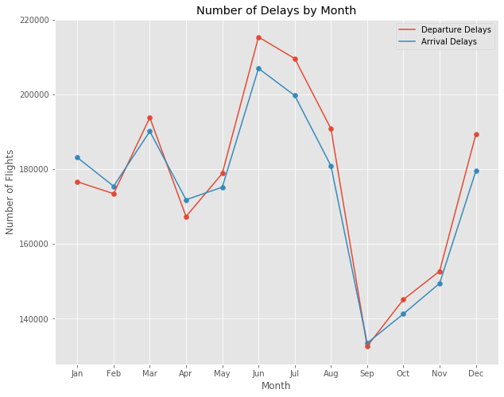

```python
# import for the viz part
import seaborn as sns
import plotly.offline as py
import plotly.figure_factory as ff
py.init_notebook_mode(connected=True)
import plotly.graph_objs as go
from plotly import tools
import branca.colormap as bcm
import branca.colormap as bcm
import folium
from folium.plugins import HeatMap

# Plotting
a = flights[['MONTH']].groupby('MONTH').size()
b = flights[flights['ARRIVAL_DELAY']> 0]['MONTH'].value_counts().sort_index()
c = flights[flights['DEPARTURE_DELAY']> 0]['MONTH'].value_counts().sort_index()

fig, ax = plt.subplots(figsize=(10, 8))

ax.plot(c.index, c.values)
ax.scatter(c.index, c.values)

ax.plot(b.index, b.values)
ax.scatter(b.index, b.values)

ax.set_xticks(b.index)
ax.set_xticklabels(['Jan', 'Feb', 'Mar', 'Apr', 'May', 'Jun', 'Jul', 'Aug', 'Sep', 'Oct', 'Nov', 'Dec'])
ax.legend(['Departure Delays', 'Arrival Delays'])
ax.set_xlabel('Month')
ax.set_ylabel('Number of Flights')
ax.set_title('Number of Delays by Month')
```

### Viz 2: Flight Delays by Day of Week

From this graph, we could see that again, the average minute of arrival delays more or less aligns with the average minute of departure delays - on those days of week that have higher average lengths of arrival delays often also have higher average lengths of departure delays. In particular, Mondays and Thursday showcase highest averages of delay times for both arrival and departure. While Saturday showcases the lowest average of delay times for both arrival and departure delays - this is interesting since by intuition, Saturdays would normally be busier for travels, and thus, higher airport traffic load, and thus possible longer delays. But this dataset tells another story.

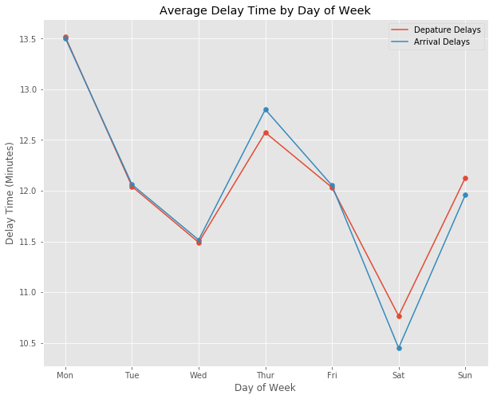

```python
# first thing first, get rid of the negative delay time as they are of low information value for this upcoming graph
flights5 = pd.DataFrame(flights)

flights5.loc[flights3['DEPARTURE_DELAY'] < 0, 'DEPARTURE_DELAY'] = 0
flights5.loc[flights3['ARRIVAL_DELAY'] < 0, 'ARRIVAL_DELAY'] = 0

# plotting
fig, ax = plt.subplots(figsize=(10, 8))

dep_day_week = flights5[['DAY_OF_WEEK', 'DEPARTURE_DELAY']].groupby('DAY_OF_WEEK').mean()
arr_day_week = flights5[['DAY_OF_WEEK', 'ARRIVAL_DELAY']].groupby('DAY_OF_WEEK').mean()

ax.plot(dep_day_week.index, dep_day_week.values)
ax.scatter(dep_day_week.index, dep_day_week.values)

ax.plot(arr_day_week .index, arr_day_week .values)
ax.scatter(arr_day_week .index, arr_day_week .values)

ax.set_xticks(arr_day_week .index)
ax.set_xticklabels(['Mon', 'Tue', 'Wed', 'Thur', 'Fri', 'Sat', 'Sun'])
ax.legend(['Depature Delays', 'Arrival Delays'])
ax.set_xlabel('Day of Week')
ax.set_ylabel('Delay Time (Minutes)')
ax.set_title('Average Delay Time by Day of Week')
```

### Viz 3: Number of Flights by Month

From this graph, we could see that February had the fewest number of flights, while July had the highest number of flights in 2015. This result might have something to do with the demand - for those months when festivals/holidays were more clustered, there tend to have more flights.

```python
F=flights.MONTH.value_counts().to_frame().reset_index().sort_values(by='index')

F.columns=['Month','Flight_Values']
Month={1: 'Jan', 2: 'Feb', 3: 'Mar', 4: 'Apr', 5: 'May',6: 'Jun',
       7: 'Jul', 8: 'Aug', 9: 'Sep', 10: 'Oct', 11: 'Nov', 12: 'Dec'}

F.Month=F.Month.map(Month)
colors = ['rosybrown', 'firebrick', 'darksalmon', 'sienna','sandybrown','bisque',
          'tan','coral','darkorange','navajowhite','darkgrey','lightpink']

trace=go.Bar(x=F.Month,y=F.Flight_Values,marker=dict(color=colors))

data=[trace]

layout = go.Layout(title='Number of Flights by Month',yaxis=dict(title='Flights Value'),height=500, width=800)

fig = go.Figure(data=data, layout=layout)

py.iplot(fig)
```

[interactive chart not shown]

### Viz 4: Correlation between Delay Reasons

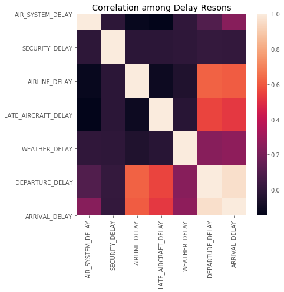

```python
delay_reason = flights[flights['AIR_SYSTEM_DELAY'].notnull() | flights['SECURITY_DELAY'].notnull() | flights['AIRLINE_DELAY'].notnull() | flights['LATE_AIRCRAFT_DELAY'].notnull() | flights['WEATHER_DELAY'].notnull()]

fig, ax = plt.subplots(figsize=(7,7))

sns.heatmap(delay_reason[['AIR_SYSTEM_DELAY', 'SECURITY_DELAY', 'AIRLINE_DELAY', 'LATE_AIRCRAFT_DELAY', 'WEATHER_DELAY', 'DEPARTURE_DELAY', 'ARRIVAL_DELAY']].corr(), ax=ax)

ax.set_title('Correlation among Delay Resons')

plt.tight_layout()
```

### Viz 5: Travel Distance and Delays

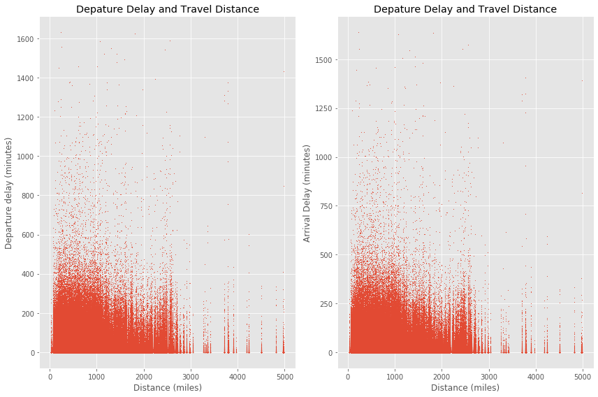

```python
flights5_sample = flights5[['DISTANCE', 'DEPARTURE_DELAY', 'ARRIVAL_DELAY']].sample(frac=0.5, random_state=0, replace=False)

fig, ax = plt.subplots(1,2, figsize=(12, 8))

ax[0].scatter(flights5_sample['DISTANCE'], flights5_sample['DEPARTURE_DELAY'], s=0.3)
ax[0].set_xlabel('Distance (miles)')
ax[0].set_ylabel('Departure delay (minutes)')
ax[0].set_title('Depature Delay and Travel Distance')

ax[1].scatter(flights5_sample['DISTANCE'], flights5_sample['ARRIVAL_DELAY'], s=0.3)
ax[1].set_xlabel('Distance (miles)')
ax[1].set_ylabel('Arrival Delay (minutes)')
ax[1].set_title('Depature Delay and Travel Distance')

plt.tight_layout()
```

### Viz 6: Airline Distribution

In 2015, WN, as in Southwest Airline had the most flights out of the 14 included airlines. DL, as in Delta is the runner-up for this, and AA, American Airline follows. VX, as in Virgin America had the least flights in 2015. This graph would hint on the capability and the size of each airline companies.

```python
#F=flights.AIRLINE.value_counts().sort_values(ascending=False)[:7]
#print(F)
#F=flights.AIRLINE.value_counts().sort_values(ascending=True)[:7]
#print(F)

F=flights.AIRLINE.value_counts().sort_values(ascending=False)[:8]
trace1 = go.Scatter(x=F.index, y=F.values,name='Most Flights',marker=dict(color='blue'))

F=flights.AIRLINE.value_counts().sort_values(ascending=True)[:7].iloc[::-1]
trace2 = go.Scatter(x=F.index, y=F.values,name='Least Flights',marker=dict(color='crimson'))

data=[trace1,trace2]
layout = dict(title = 'Airline Distribution')
fig = dict(data=data,layout = layout)
py.iplot(fig)
```

[interactive chart not shown]

### Viz 7: Flight Cancellations by Month

From this graph, we could see that Febuary had the highest percentage of cancelled flights in 2015. More background information would be needed to explain this.

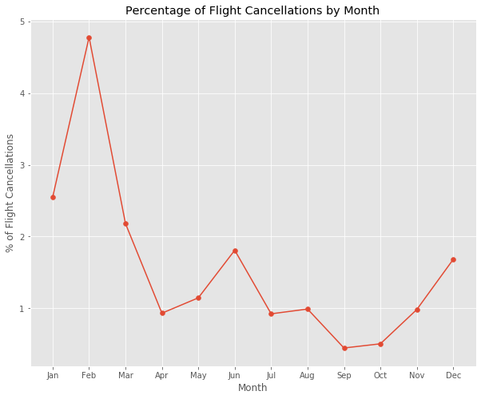

```python
cancelled = flights[flights["CANCELLED"] == 1]

cancelled_by_month = cancelled['MONTH'].value_counts() / flights['MONTH'].value_counts() * 100

plt.style.use('ggplot')

fig, ax = plt.subplots(figsize=(10, 8))

ax.plot(cancelled_by_month.index, cancelled_by_month.values)
ax.scatter(cancelled_by_month.index, cancelled_by_month.values)

ax.set_xticks(cancelled_by_month.index)
ax.set_xticklabels(['Jan', 'Feb', 'Mar', 'Apr', 'May', 'Jun', 'Jul', 'Aug', 'Sep', 'Oct', 'Nov', 'Dec'])
ax.set_xlabel('Month')
ax.set_ylabel('% of Flight Cancellations')
ax.set_title('Percentage of Flight Cancellations by Month')
```

### Viz 8: Cancelled Flights by Top Ten Airports and Reasons

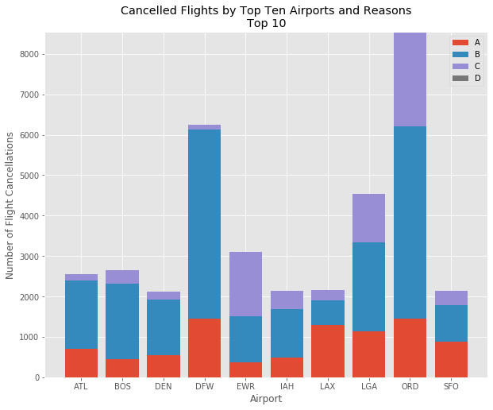

```python
# first get the top ten airports with most cancelled flights.
# since there would not be destination airport for cancelled flights, focus on the origin airport here.
cancelled_aiport_top = cancelled['ORIGIN_AIRPORT'].value_counts().head(10).to_frame().rename(columns={'ORIGIN_AIRPORT': 'count_cancel'}).index

# extract cancellation reason
cancelled['reason'] = cancelled['CANCELLATION_REASON'].map({'A': 'Airline/Aircraft', 'B': 'Weather', 'C': 'Air System', 'D': 'Security'})
df_viz = cancelled[['ORIGIN_AIRPORT', "CANCELLED"]]

# compile with airport
temp = cancelled[['ORIGIN_AIRPORT', 'CANCELLATION_REASON']].groupby(['ORIGIN_AIRPORT', 'CANCELLATION_REASON']).size().reset_index().rename(columns={0: 'temp_count'})
temp2 = temp[temp['ORIGIN_AIRPORT'].isin(cancelled_aiport_top)].set_index('ORIGIN_AIRPORT').pivot(columns='CANCELLATION_REASON', values='temp_count')

fig, ax = plt.subplots(figsize=(10, 8))

for i, j in enumerate(temp2):
    if i == 0:
        ax.bar(temp2.index, temp2[j])
    else:
        ax.bar(temp2.index, temp2[j], bottom=temp2[list(temp2.columns[0: i])].sum(axis=1))

ax.legend(temp2.columns)
ax.set_xlabel('Airport')
ax.set_ylabel('Number of Flight Cancellations')
ax.set_title('Cancelled Flights by Top Ten Airports and Reasons\nTop 10')
```

### Viz 9: Distribution of Flight Speeds by Airline

*Lastly, I am intrigued to find out that how the flight speeds differ by airline companies. From the boxplot below, we could see that Alaska Airline, Frontier Airline, Spirit Airline, and United Airline have the highest median flight speeds. It is interesting to see that two airline companies (Spirit, and Frontier) here are low-cost carriers.

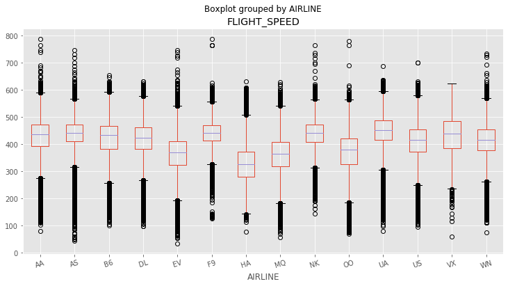

```python
flights['FLIGHT_SPEED'] = 60*flights['DISTANCE'] / flights['AIR_TIME']

flights[['AIRLINE', 'FLIGHT_SPEED']].boxplot(column = 'FLIGHT_SPEED', by = 'AIRLINE', figsize = (12,6), rot = 18)
```

### Final Note

*Since this case involves large amount of information, there are for sure many more other patterns and facts that we could dig from it. Other aspects that sound interesting are:*

Which airports have the highest on-time departure rate and the highest on-time arrival rate? Which airports have the lowest? Is taxi time related to delay - if so, in what way? Is taxi time related to month of year, and day or week? If so, in what way? Do the airlines with higher numbers of flights tend to have more delays? What about cancellations? Do the airlines with higher numbers of delays tend to have relatively higher number of flight cancellations? Answer to this question might give insight to how the airline companies operate.

**etc.**